# Venezuela Tweet Clean Up & Analysis

Brian and Ash

April 16, 2018

Ensure that the following packages are installed and loaded:“twitteR”, “rtweet”, “dplyr”, “tidyr”

## Environment Set Up

Information needed to pull data from twitter: CONSUMER_KEY, CONSUMER SECRET,ACCESS_TOKEN, ACCESS_SECRET. This willl vary based on your own twitter account.

Creates the authetication to the twitter API, without a valid authentication the twitter pulls will fail.

```r
setup_twitter_oauth(consumer_key, consumer_secret, access_token, access_secret)
```

```
## [1] "Using direct authentication"
```

Set Up Path. Ensure to change the variable myPath with your own path accordingly.

## Getting and Appending Data

Read the data that has been saved previously, to ensure that we can append new data.

```r
test <- read.csv(paste(myPath,"tweets.df.all.csv", sep=""), header = TRUE,stringsAsFactors = FALSE)
str(test)
```

```
## 'data.frame':    139338 obs. of  17 variables:
##  $ text         : chr  "RT @VatoRegio69: Enmascarados, maduro chingándose a chavito. Si quieres verga, la aguantas cabrón. https://t.co/dnYRDAF97m" "RT @DanielBlancoPz: Smartmatic cerró operaciones en Venezuela debido al fraude cometido por el Centro Nacional "| __truncated__ "Florida aprobó proy…
##  $ favorited    : logi  FALSE FALSE FALSE FALSE FALSE FALSE ...
##  $ favoriteCount: int  0 0 0 0 0 0 0 0 0 0 ...
##  $ replyToSN    : chr  NA NA NA NA ...
##  $ created      : chr  "2018-03-09 00:20:00" "2018-03-09 00:20:00" "2018-03-09 00:20:00" "2018-03-09 00:20:00" ...
##  $ truncated    : logi  FALSE FALSE FALSE FALSE FALSE FALSE ...
##  $ replyToSID   : num  NA NA NA NA NA NA NA NA NA NA ...
##  $ id           : num  9.72e+17 9.72e+17 9.72e+17 9.72e+17 9.72e+17 ...
##  $ replyToUID   : num  NA NA NA NA NA NA NA NA NA NA ...
##  $ statusSource : chr  "<a href=\"http://twitter.com/download/android\" rel=\"nofollow\">Twitter for Android</a>" "<a href=\"https://mobile.twitter.com\" rel=\"nofollow\">Twitter Lite</a>" "<a href=\"http://publicize.wp.com/\" rel=\"nofollow\">WordPress.com</a>" "<a href=\"http://twitter.com\" re…
##  $ screenName   : chr  "Rubielhg" "giusyff" "NoticiasVenezue" "sordoiturriza" ...
##  $ retweetCount : int  182 2640 0 0 30 3 457 1041 275 0 ...
##  $ isRetweet    : logi  TRUE TRUE FALSE FALSE TRUE TRUE ...
##  $ retweeted    : logi  FALSE FALSE FALSE FALSE FALSE FALSE ...
##  $ longitude    : num  NA NA NA NA NA NA NA NA NA NA ...
##  $ latitude     : num  NA NA NA NA NA NA NA NA NA NA ...
##  $ source_data  : chr  "tweets.df500" "tweets.df500" "tweets.df500" "tweets.df500" ...
```

Converts the created column into a Date Type instead of Character.

```r
#test <- mutate(test,created = as.POSIXct(test$created, format ="%m/%d/%Y %H:%M"))
test <- mutate(test,created = as.POSIXct(test$created))
```

Ensure that there are no NAs in the Created field.

```r
str(test)
```

```
## 'data.frame':    139338 obs. of  17 variables:
##  $ text         : chr  "RT @VatoRegio69: Enmascarados, maduro chingándose a chavito. Si quieres verga, la aguantas cabrón. https://t.co/dnYRDAF97m" "RT @DanielBlancoPz: Smartmatic cerró operaciones en Venezuela debido al fraude cometido por el Centro Nacional "| __truncated__ "Florida aprobó proy…
##  $ favorited    : logi  FALSE FALSE FALSE FALSE FALSE FALSE ...
##  $ favoriteCount: int  0 0 0 0 0 0 0 0 0 0 ...
##  $ replyToSN    : chr  NA NA NA NA ...
##  $ created      : POSIXct, format: "2018-03-09 00:20:00" "2018-03-09 00:20:00" ...
##  $ truncated    : logi  FALSE FALSE FALSE FALSE FALSE FALSE ...
##  $ replyToSID   : num  NA NA NA NA NA NA NA NA NA NA ...
##  $ id           : num  9.72e+17 9.72e+17 9.72e+17 9.72e+17 9.72e+17 ...
##  $ replyToUID   : num  NA NA NA NA NA NA NA NA NA NA ...
##  $ statusSource : chr  "<a href=\"http://twitter.com/download/android\" rel=\"nofollow\">Twitter for Android</a>" "<a href=\"https://mobile.twitter.com\" rel=\"nofollow\">Twitter Lite</a>" "<a href=\"http://publicize.wp.com/\" rel=\"nofollow\">WordPress.com</a>" "<a href=\"http://twitter.com\" re…
##  $ screenName   : chr  "Rubielhg" "giusyff" "NoticiasVenezue" "sordoiturriza" ...
##  $ retweetCount : int  182 2640 0 0 30 3 457 1041 275 0 ...
##  $ isRetweet    : logi  TRUE TRUE FALSE FALSE TRUE TRUE ...
##  $ retweeted    : logi  FALSE FALSE FALSE FALSE FALSE FALSE ...
##  $ longitude    : num  NA NA NA NA NA NA NA NA NA NA ...
##  $ latitude     : num  NA NA NA NA NA NA NA NA NA NA ...
##  $ source_data  : chr  "tweets.df500" "tweets.df500" "tweets.df500" "tweets.df500" ...
```

```r
test[is.na(test$created),]
```

```
##  [1] text          favorited     favoriteCount replyToSN     created
##  [6] truncated     replyToSID    id            replyToUID    statusSource
## [11] screenName    retweetCount  isRetweet     retweeted     longitude
## [16] latitude      source_data
## <0 rows> (or 0-length row.names)
```

Pulls Data from Twitter based on specified keywords or hashtags, specifying how many tweets to pull, in both english and spanish, and saves each pull into a variable. Things to note: Twitter limits the amount of pulls one can do within 15 minutes.

```r
tweets3000_daily <- searchTwitter("Venezuela OR #Venezuela OR Maduro OR #Maduro", n = 3000, retryOnRateLimit = 120 )
```

Convert the pulled tweets, which are class type list, from the previous step into a Data Frame in order to analyze the data.

```r
tweets.df3000 <- twListToDF(tweets3000_daily)
```

We need to add a column to each data frame that adds the date the tweet was pulled. We store this in a new variable so we won’t edit the source.

```r
tweets.df3000.ec <- mutate(tweets.df3000,source_data=date())
```

Append the recently pulled data with the previously loaded data.

```r
test_upd <- rbind(test,tweets.df3000.ec)
```

Quickly analyze the newly appended data frame

```r
str(test_upd)
```

```
## 'data.frame':    142338 obs. of  17 variables:
##  $ text         : chr  "RT @VatoRegio69: Enmascarados, maduro chingándose a chavito. Si quieres verga, la aguantas cabrón. https://t.co/dnYRDAF97m" "RT @DanielBlancoPz: Smartmatic cerró operaciones en Venezuela debido al fraude cometido por el Centro Nacional "| __truncated__ "Florida aprobó proy…
##  $ favorited    : logi  FALSE FALSE FALSE FALSE FALSE FALSE ...
##  $ favoriteCount: num  0 0 0 0 0 0 0 0 0 0 ...
##  $ replyToSN    : chr  NA NA NA NA ...
##  $ created      : POSIXct, format: "2018-03-09 00:20:00" "2018-03-09 00:20:00" ...
##  $ truncated    : logi  FALSE FALSE FALSE FALSE FALSE FALSE ...
##  $ replyToSID   : chr  NA NA NA NA ...
##  $ id           : chr  "9.72e+17" "9.72e+17" "9.72e+17" "9.72e+17" ...
##  $ replyToUID   : chr  NA NA NA NA ...
##  $ statusSource : chr  "<a href=\"http://twitter.com/download/android\" rel=\"nofollow\">Twitter for Android</a>" "<a href=\"https://mobile.twitter.com\" rel=\"nofollow\">Twitter Lite</a>" "<a href=\"http://publicize.wp.com/\" rel=\"nofollow\">WordPress.com</a>" "<a href=\"http://twitter.com\" re…
##  $ screenName   : chr  "Rubielhg" "giusyff" "NoticiasVenezue" "sordoiturriza" ...
##  $ retweetCount : num  182 2640 0 0 30 ...
##  $ isRetweet    : logi  TRUE TRUE FALSE FALSE TRUE TRUE ...
##  $ retweeted    : logi  FALSE FALSE FALSE FALSE FALSE FALSE ...
##  $ longitude    : chr  NA NA NA NA ...
##  $ latitude     : chr  NA NA NA NA ...
##  $ source_data  : chr  "tweets.df500" "tweets.df500" "tweets.df500" "tweets.df500" ...
```

We confirm that there are no N/As in the created column. Should result in 0 rows.

```r
test_upd[is.na(test_upd$created),]
```

```
##  [1] text          favorited     favoriteCount replyToSN     created
##  [6] truncated     replyToSID    id            replyToUID    statusSource
## [11] screenName    retweetCount  isRetweet     retweeted     longitude
## [16] latitude      source_data
## <0 rows> (or 0-length row.names)
```

Remove duplicates based on text, created, screenName, statusSource.

```r
test_rmv_dups <- distinct(test_upd, text, created, screenName,statusSource,.keep_all = TRUE)
str(test_rmv_dups)
```

```
## 'data.frame':    140400 obs. of  17 variables:
##  $ text         : chr  "RT @VatoRegio69: Enmascarados, maduro chingándose a chavito. Si quieres verga, la aguantas cabrón. https://t.co/dnYRDAF97m" "RT @DanielBlancoPz: Smartmatic cerró operaciones en Venezuela debido al fraude cometido por el Centro Nacional "| __truncated__ "Florida aprobó proy…
##  $ favorited    : logi  FALSE FALSE FALSE FALSE FALSE FALSE ...
##  $ favoriteCount: num  0 0 0 0 0 0 0 0 0 0 ...
##  $ replyToSN    : chr  NA NA NA NA ...
##  $ created      : POSIXct, format: "2018-03-09 00:20:00" "2018-03-09 00:20:00" ...
##  $ truncated    : logi  FALSE FALSE FALSE FALSE FALSE FALSE ...
##  $ replyToSID   : chr  NA NA NA NA ...
##  $ id           : chr  "9.72e+17" "9.72e+17" "9.72e+17" "9.72e+17" ...
##  $ replyToUID   : chr  NA NA NA NA ...
##  $ statusSource : chr  "<a href=\"http://twitter.com/download/android\" rel=\"nofollow\">Twitter for Android</a>" "<a href=\"https://mobile.twitter.com\" rel=\"nofollow\">Twitter Lite</a>" "<a href=\"http://publicize.wp.com/\" rel=\"nofollow\">WordPress.com</a>" "<a href=\"http://twitter.com\" re…
##  $ screenName   : chr  "Rubielhg" "giusyff" "NoticiasVenezue" "sordoiturriza" ...
##  $ retweetCount : num  182 2640 0 0 30 ...
##  $ isRetweet    : logi  TRUE TRUE FALSE FALSE TRUE TRUE ...
##  $ retweeted    : logi  FALSE FALSE FALSE FALSE FALSE FALSE ...
##  $ longitude    : chr  NA NA NA NA ...
##  $ latitude     : chr  NA NA NA NA ...
##  $ source_data  : chr  "tweets.df500" "tweets.df500" "tweets.df500" "tweets.df500" ...
```

Ensuring that there are no NAs in the Created column

```r
test_rmv_dups[is.na(test_rmv_dups$created),]
```

```
##  [1] text          favorited     favoriteCount replyToSN     created
##  [6] truncated     replyToSID    id            replyToUID    statusSource
## [11] screenName    retweetCount  isRetweet     retweeted     longitude
## [16] latitude      source_data
## <0 rows> (or 0-length row.names)
```

Store the tweets with the duplicates removed

```r
write.csv(test_rmv_dups, file = (paste(myPath,"tweets.df.all.csv", sep="")),row.names=FALSE)
```

## Cleaning the Data

Looking at the StatusSource variable, it has the following format:

```r
head(select(test_rmv_dups,statusSource),5)
```

```
##                                                                           statusSource
## 1 <a href="http://twitter.com/download/android" rel="nofollow">Twitter for Android</a>
## 2                 <a href="https://mobile.twitter.com" rel="nofollow">Twitter Lite</a>
## 3                  <a href="http://publicize.wp.com/" rel="nofollow">WordPress.com</a>
## 4                   <a href="http://twitter.com" rel="nofollow">Twitter Web Client</a>
## 5   <a href="http://twitter.com/download/iphone" rel="nofollow">Twitter for iPhone</a>
```

Seperate statusSource based on the sep > in order to see the platform of the Tweet (Android, Iphone, Ipad)

```r
test_rmv_dups_sep <- separate(test_rmv_dups,statusSource, c("URL","Platform"),sep=">")
head(select(test_rmv_dups_sep,URL, Platform),5)
```

```
##                                                            URL
## 1 <a href="http://twitter.com/download/android" rel="nofollow"
## 2          <a href="https://mobile.twitter.com" rel="nofollow"
## 3            <a href="http://publicize.wp.com/" rel="nofollow"
## 4                  <a href="http://twitter.com" rel="nofollow"
## 5  <a href="http://twitter.com/download/iphone" rel="nofollow"
##                 Platform
## 1 Twitter for Android</a
## 2        Twitter Lite</a
## 3       WordPress.com</a
## 4  Twitter Web Client</a
## 5  Twitter for iPhone</a
```

We need to continue the clean up of the Platform column by removing the additional characters at the end.

```r
test_rmv_dups_sep1 <- separate(test_rmv_dups_sep,Platform, c("Platform","Remove"),sep="<")
head(select(test_rmv_dups_sep1,Platform, Remove),5)
```

```
##              Platform Remove
## 1 Twitter for Android     /a
## 2        Twitter Lite     /a
## 3       WordPress.com     /a
## 4  Twitter Web Client     /a
## 5  Twitter for iPhone     /a
```

Remove the unnecasarry columns that resulted from separating statusSource.

```r
test_rmv_dups_sep2 <- select(test_rmv_dups_sep1,-URL,-Remove)
str(test_rmv_dups_sep2)
```

```
## 'data.frame':    140400 obs. of  17 variables:
##  $ text         : chr  "RT @VatoRegio69: Enmascarados, maduro chingándose a chavito. Si quieres verga, la aguantas cabrón. https://t.co/dnYRDAF97m" "RT @DanielBlancoPz: Smartmatic cerró operaciones en Venezuela debido al fraude cometido por el Centro Nacional "| __truncated__ "Florida aprobó proy…
##  $ favorited    : logi  FALSE FALSE FALSE FALSE FALSE FALSE ...
##  $ favoriteCount: num  0 0 0 0 0 0 0 0 0 0 ...
##  $ replyToSN    : chr  NA NA NA NA ...
##  $ created      : POSIXct, format: "2018-03-09 00:20:00" "2018-03-09 00:20:00" ...
##  $ truncated    : logi  FALSE FALSE FALSE FALSE FALSE FALSE ...
##  $ replyToSID   : chr  NA NA NA NA ...
##  $ id           : chr  "9.72e+17" "9.72e+17" "9.72e+17" "9.72e+17" ...
##  $ replyToUID   : chr  NA NA NA NA ...
##  $ Platform     : chr  "Twitter for Android" "Twitter Lite" "WordPress.com" "Twitter Web Client" ...
##  $ screenName   : chr  "Rubielhg" "giusyff" "NoticiasVenezue" "sordoiturriza" ...
##  $ retweetCount : num  182 2640 0 0 30 ...
##  $ isRetweet    : logi  TRUE TRUE FALSE FALSE TRUE TRUE ...
##  $ retweeted    : logi  FALSE FALSE FALSE FALSE FALSE FALSE ...
##  $ longitude    : chr  NA NA NA NA ...
##  $ latitude     : chr  NA NA NA NA ...
##  $ source_data  : chr  "tweets.df500" "tweets.df500" "tweets.df500" "tweets.df500" ...
```

## Manipulating the Data

Create a DF with only the Platform used

```r
commonPlatform <- select(test_rmv_dups_sep2,Platform)
```

Create a variable that holds the frequency of the common platforms used Source: https://stackoverflow.com/questions/24576515/relative-frequencies-proportions-with-dplyr/24576703

```r
commonPlatform_freq <- summarize(group_by(commonPlatform,Platform),freq=n())
```

Arrange the common platform in descending order, to see which type of device/platform was most used.

```r
commonPlatform_freq_desc <- arrange(commonPlatform_freq, desc(freq))
commonPlatform_freq_desc
```

```
## # A tibble: 433 x 2
##    Platform             freq
##    <chr>               <int>
##  1 Twitter for Android 67443
##  2 Twitter Web Client  29979
##  3 Twitter for iPhone  20115
##  4 Twitter Lite         5364
##  5 TweetDeck            3449
##  6 Twitter for iPad     2680
##  7 Facebook              857
##  8 Hootsuite             824
##  9 Mobile Web (M2)       816
## 10 IFTTT                 814
## # ... with 423 more rows
```

Add the proportion to the common platfrom to show the most used platform

```r
commonPlatform_prop <- mutate(commonPlatform_freq_desc,prop=freq*100/sum(freq))
commonPlatform_prop
```

```
## # A tibble: 433 x 3
##    Platform             freq   prop
##    <chr>               <int>  <dbl>
##  1 Twitter for Android 67443 48.0
##  2 Twitter Web Client  29979 21.4
##  3 Twitter for iPhone  20115 14.3
##  4 Twitter Lite         5364  3.82
##  5 TweetDeck            3449  2.46
##  6 Twitter for iPad     2680  1.91
##  7 Facebook              857  0.610
##  8 Hootsuite             824  0.587
##  9 Mobile Web (M2)       816  0.581
## 10 IFTTT                 814  0.580
## # ... with 423 more rows
```

Create a DF with only the screenNames

```r
commonUsers <- select(test_rmv_dups_sep2,screenName)
```

Create a variable that holds the frequency of the users (i.e. Show’s the amount of tweets each user has in the data set).

```r
commonUsers_freq <- summarize(group_by(commonUsers,screenName),freq=n())
```

Arrange the commonUsers_freq by descending order, to see the screename with most tweets.

```r
commonUsers_freq_desc <- arrange(commonUsers_freq,desc(freq))
commonUsers_freq_desc
```

```
## # A tibble: 63,963 x 2
##    screenName       freq
##    <chr>           <int>
##  1 MCRC_Venezuela    284
##  2 NoticiasVenezue   224
##  3 notiven           190
##  4 la_patilla        185
##  5 segurosybanca     155
##  6 Nuevomedio        146
##  7 DolarToday        142
##  8 ContextoDiario    119
##  9 ElNacionalWeb     117
## 10 contrapuntovzla    95
## # ... with 63,953 more rows
```

Add the proportion to the common screenNames / users to show the percentages.

```r
commonUsers_prop <- mutate(commonUsers_freq_desc,prop=freq*100/sum(freq))
commonUsers_prop
```

```
## # A tibble: 63,963 x 3
##    screenName       freq   prop
##    <chr>           <int>  <dbl>
##  1 MCRC_Venezuela    284 0.202
##  2 NoticiasVenezue   224 0.160
##  3 notiven           190 0.135
##  4 la_patilla        185 0.132
##  5 segurosybanca     155 0.110
##  6 Nuevomedio        146 0.104
##  7 DolarToday        142 0.101
##  8 ContextoDiario    119 0.0848
##  9 ElNacionalWeb     117 0.0833
## 10 contrapuntovzla    95 0.0677
## # ... with 63,953 more rows
```

## Plotting the Data

### Top Users/ScreenNames

We want to show the users (screenNames) with top tweets.

```r
commonUsers_prop
```

```
## # A tibble: 63,963 x 3
##    screenName       freq   prop
##    <chr>           <int>  <dbl>
##  1 MCRC_Venezuela    284 0.202
##  2 NoticiasVenezue   224 0.160
##  3 notiven           190 0.135
##  4 la_patilla        185 0.132
##  5 segurosybanca     155 0.110
##  6 Nuevomedio        146 0.104
##  7 DolarToday        142 0.101
##  8 ContextoDiario    119 0.0848
##  9 ElNacionalWeb     117 0.0833
## 10 contrapuntovzla    95 0.0677
## # ... with 63,953 more rows
```

Create a Data Frame with the top two Users. In this case we are hard coding them.

```r
MCRC_ts <- filter(test_rmv_dups_sep2, screenName=="MCRC_Venezuela" | screenName=="NoticiasVenezue")
```

Line Graph showing the number of tweets of the top 2 users, using qplot

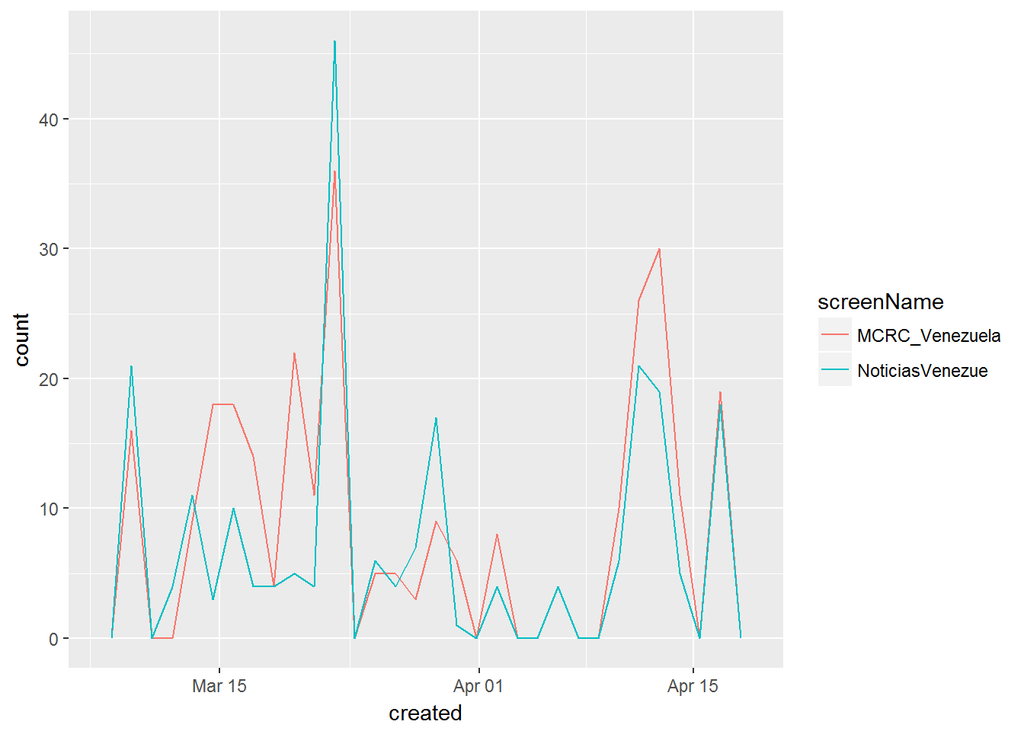

```r
qplot(created, data = MCRC_ts, geom="freqpoly", colour = screenName)
```

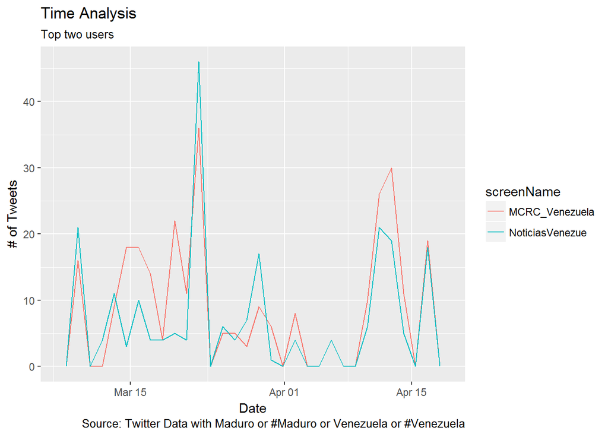

```r
ggplot(MCRC_ts, aes(x=created,colour=screenName))+geom_freqpoly()+labs(title= "Time Analysis", subtitle="Top two users",x="Date", y="# of Tweets", caption="Source: Twitter Data with Maduro or #Maduro or Venezuela or #Venezuela")
```

Stacked Bar chart showing the number of tweets of the top 2 users.

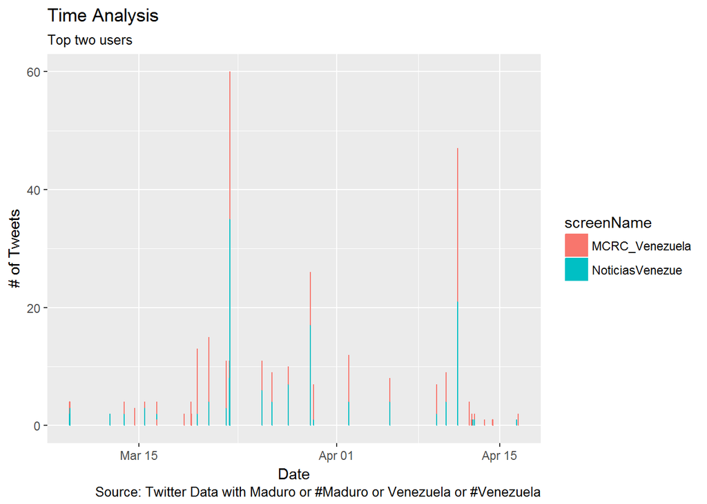

```r
ggplot(MCRC_ts, aes(x=created, colour=screenName))+
  geom_bar(aes(fill = screenName), width = 30)+labs(title= "Time Analysis", subtitle="Top two users",x="Date", y="# of Tweets", caption="Source: Twitter Data with Maduro or #Maduro or Venezuela or #Venezuela")
```

### Platforms

```r
commonPlatform_prop
```

```
## # A tibble: 433 x 3
##    Platform             freq   prop
##    <chr>               <int>  <dbl>
##  1 Twitter for Android 67443 48.0
##  2 Twitter Web Client  29979 21.4
##  3 Twitter for iPhone  20115 14.3
##  4 Twitter Lite         5364  3.82
##  5 TweetDeck            3449  2.46
##  6 Twitter for iPad     2680  1.91
##  7 Facebook              857  0.610
##  8 Hootsuite             824  0.587
##  9 Mobile Web (M2)       816  0.581
## 10 IFTTT                 814  0.580
## # ... with 423 more rows
```

Creating a Pie Chart of all Platforms >1% First we need to aggragate all the Platforms that are under 1% into an Other Category

```r
df1 <- filter(commonPlatform_prop, prop>1)
df2 <- filter(commonPlatform_prop, prop<1)
sumfreq <- sum(df2$freq)
sumprop <- sum(df2$prop)
df3 <- data.frame(Platform='Other',freq = sumfreq, prop=sumprop)
df4 <- rbind(df1,df3)
```

Confirm that the prop of df4 = 100

```r
df4
```

```
## # A tibble: 7 x 3
##   Platform             freq  prop
##   <chr>               <int> <dbl>
## 1 Twitter for Android 67443 48.0
## 2 Twitter Web Client  29979 21.4
## 3 Twitter for iPhone  20115 14.3
## 4 Twitter Lite         5364  3.82
## 5 TweetDeck            3449  2.46
## 6 Twitter for iPad     2680  1.91
## 7 Other               11370  8.10
```

```r
sum(df4$prop)
```

```
## [1] 100
```

Creating first a bar chart. Source: http://www.sthda.com/english/wiki/ggplot2-pie-chart-quick-start-guide-r-software-and-data-visualization

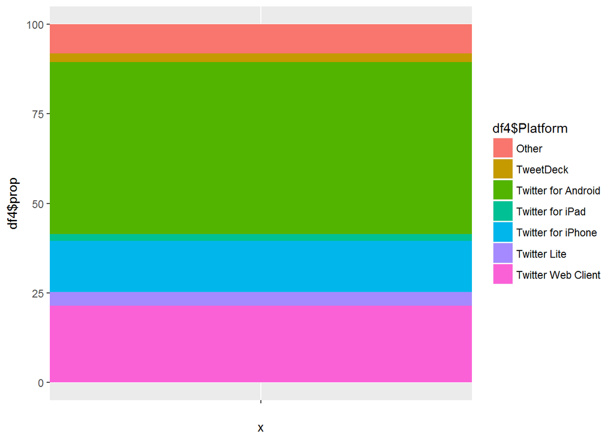

```r
platformBar<- ggplot(df4, aes(x="", y=df4$prop, fill=df4$Platform))+ geom_bar(width = 1, stat = "identity")
platformBar
```

Create the pie chart. Source: http://www.sthda.com/english/wiki/ggplot2-pie-chart-quick-start-guide-r-software-and-data-visualization

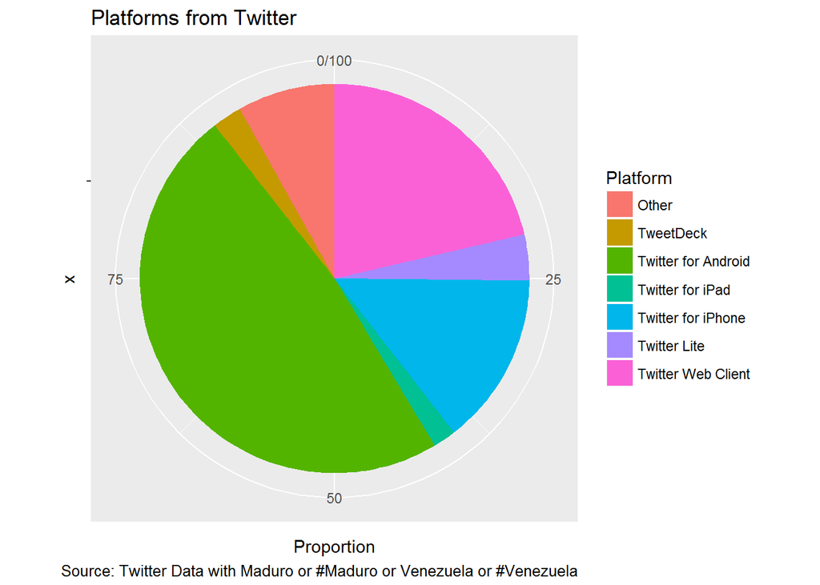

```r
platformPie <- platformBar + coord_polar("y", start=0)
platformPie + labs(title= "Platforms from Twitter",y="Proportion", fill="Platform", caption="Source: Twitter Data with Maduro or #Maduro or Venezuela or #Venezuela")
```

Creates a Dot Plot, showing the number of tweets by platform

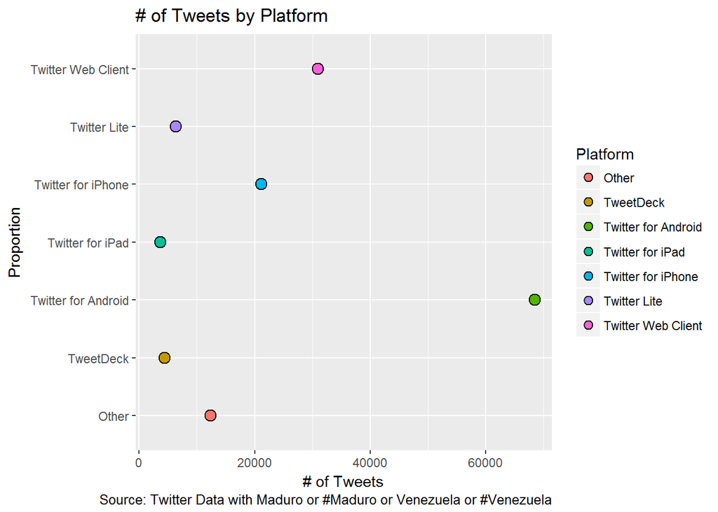

```r
ggplot(arrange(df4,df4$freq), aes(x = freq, y = Platform, fill=Platform)) + geom_dotplot(binaxis = "y", stackgroups = FALSE, binwidth = .2, method = "histodot") + labs(title= "# of Tweets by Platform",y="Proportion", x="# of Tweets", fill="Platform", caption="Source: Twitter Data with Maduro or #Maduro or Venezuela or #Venezuela")
```

## Tweet Geo-location Analysis

We want to find out the location of the tweets based on the latitude and longtiude variables/columns. We removed the NAs using the drop_na tidyr function. Source: https://stackoverflow.com/questions/4862178/remove-rows-with-nas-missing-values-in-data-frame  
Another way to accomplish this task is to use the following dplyr filter function: test_lat_long <- filter(test_lat_long_1, !is.na(latitude), !is.na(longitude))

```r
test_lat_long1 <- drop_na(test_rmv_dups_sep2, latitude, longitude)
str(test_lat_long1)
```

```
## 'data.frame':    171 obs. of  17 variables:
##  $ text         : chr  "⒈ Hogares de la Patria\n⒉ Frente Amplio Venezuela Libre\n⒊ #YoSoyCampusLibertad\n⒋ "| __truncated__ "#mujer en Venezuela https://t.co/fWUFhFKcAk" "Buenas Tardes gente <ed> ½<ed>¸<ed> ½<ed>² ☀ a"| __truncated__ "El combo frao,  tas cla.  #tbt en Venezuela https://t.co/kzR6c…
##  $ favorited    : logi  FALSE FALSE FALSE FALSE FALSE FALSE ...
##  $ favoriteCount: num  0 0 0 0 0 0 0 1 0 0 ...
##  $ replyToSN    : chr  NA NA NA NA ...
##  $ created      : POSIXct, format: "2018-03-09 00:20:00" "2018-03-09 00:18:00" ...
##  $ truncated    : logi  TRUE FALSE FALSE FALSE FALSE TRUE ...
##  $ replyToSID   : chr  NA NA NA NA ...
##  $ id           : chr  "9.72e+17" "9.72e+17" "9.72e+17" "9.72e+17" ...
##  $ replyToUID   : chr  NA NA NA NA ...
##  $ Platform     : chr  "Es Tendencia en Venezuela" "Instagram" "Instagram" "Instagram" ...
##  $ screenName   : chr  "trendinaliaVE" "dj_viloria" "Bogoaccesorios" "IsraelRibas" ...
##  $ retweetCount : num  0 0 0 0 0 0 0 1 0 0 ...
##  $ isRetweet    : logi  FALSE FALSE FALSE FALSE FALSE FALSE ...
##  $ retweeted    : logi  FALSE FALSE FALSE FALSE FALSE FALSE ...
##  $ longitude    : chr  "-66.8983" "-65" "-67.59055556" "-65" ...
##  $ latitude     : chr  "10.496" "8" "10.24861111" "8" ...
##  $ source_data  : chr  "tweets.df500" "tweets.df500" "tweets.df3000" "tweets.df3000" ...
```

Save test_lat_long df as a CSV file to upload into ArcGIS online and created 2 maps.

```r
write.csv(test_lat_long1,file = paste(myPath,"test_lat_long.csv",sep=""), row.names = FALSE)
```

Created maps using ArcGIS with tweets from 3/20/18:  
[Venezuelan Tweets Heat Map](https://github.com/perezba/rtweetvenba/blob/master/HeatMap_Ventweets.PNG?raw=true)  
[Venezuelan Tweets Platform](https://github.com/perezba/rtweetvenba/blob/master/Map_Ventweets.PNG)

## References and Notes:

- HTML file was knitted directly from the R script using rmarkdown render function:
- rmarkdown::render(paste(myPath,“ven_tweet.R”,sep=“”))
- Source: http://brooksandrew.github.io/simpleblog/articles/render-reports-directly-from-R-scripts/

## Change Tracker

- 3/26/18: Created HTML file to illustrate the process to collect, clean and manipulate twitter data
- 4/16/18: Added the graphs, and the plotting sections.